# Risk Factor Analysis

## Outcome Variable

**Outcome Variable:** pers_wasted624

## Predictor Variables

**Intervention Variable:** ever_underweight06

**Adjustment Set:**

- sex
- arm
- enstunt
- month
- brthmon
- vagbrth
- single
- W_gagebrth
- W_birthwt
- W_birthlen
- W_mage
- W_mhtcm
- W_meducyrs
- W_feducyrs
- W_parity
- delta_month
- delta_brthmon
- delta_vagbrth
- delta_single
- delta_W_gagebrth
- delta_W_birthwt
- delta_W_birthlen
- delta_W_mage
- delta_W_mhtcm
- delta_W_meducyrs
- delta_W_feducyrs
- delta_W_parity

## Stratifying Variables

The analysis was stratified on these variable(s):

- studyid
- country

## Data Summary

| studyid | country | ever_underweight06 | pers_wasted624 | n_cell | n |
| --- | --- | --- | --- | --- | --- |
| ki0047075b-MAL-ED | BANGLADESH | 0 | 0 | 161 | 239 |
| ki0047075b-MAL-ED | BANGLADESH | 0 | 1 | 5 | 239 |
| ki0047075b-MAL-ED | BANGLADESH | 1 | 0 | 60 | 239 |
| ki0047075b-MAL-ED | BANGLADESH | 1 | 1 | 13 | 239 |
| ki0047075b-MAL-ED | BRAZIL | 0 | 0 | 188 | 202 |
| ki0047075b-MAL-ED | BRAZIL | 0 | 1 | 2 | 202 |
| ki0047075b-MAL-ED | BRAZIL | 1 | 0 | 12 | 202 |
| ki0047075b-MAL-ED | BRAZIL | 1 | 1 | 0 | 202 |
| ki0047075b-MAL-ED | INDIA | 0 | 0 | 142 | 234 |
| ki0047075b-MAL-ED | INDIA | 0 | 1 | 1 | 234 |
| ki0047075b-MAL-ED | INDIA | 1 | 0 | 64 | 234 |
| ki0047075b-MAL-ED | INDIA | 1 | 1 | 27 | 234 |
| ki0047075b-MAL-ED | NEPAL | 0 | 0 | 197 | 234 |
| ki0047075b-MAL-ED | NEPAL | 0 | 1 | 0 | 234 |
| ki0047075b-MAL-ED | NEPAL | 1 | 0 | 35 | 234 |
| ki0047075b-MAL-ED | NEPAL | 1 | 1 | 2 | 234 |
| ki0047075b-MAL-ED | PERU | 0 | 0 | 222 | 264 |
| ki0047075b-MAL-ED | PERU | 0 | 1 | 1 | 264 |
| ki0047075b-MAL-ED | PERU | 1 | 0 | 40 | 264 |
| ki0047075b-MAL-ED | PERU | 1 | 1 | 1 | 264 |
| ki0047075b-MAL-ED | SOUTH AFRICA | 0 | 0 | 218 | 258 |
| ki0047075b-MAL-ED | SOUTH AFRICA | 0 | 1 | 0 | 258 |
| ki0047075b-MAL-ED | SOUTH AFRICA | 1 | 0 | 38 | 258 |
| ki0047075b-MAL-ED | SOUTH AFRICA | 1 | 1 | 2 | 258 |
| ki0047075b-MAL-ED | TANZANIA, UNITED REPUBLIC OF | 0 | 0 | 206 | 244 |
| ki0047075b-MAL-ED | TANZANIA, UNITED REPUBLIC OF | 0 | 1 | 0 | 244 |
| ki0047075b-MAL-ED | TANZANIA, UNITED REPUBLIC OF | 1 | 0 | 38 | 244 |
| ki0047075b-MAL-ED | TANZANIA, UNITED REPUBLIC OF | 1 | 1 | 0 | 244 |
| ki1000108-CMC-V-BCS-2002 | INDIA | 0 | 0 | 186 | 373 |
| ki1000108-CMC-V-BCS-2002 | INDIA | 0 | 1 | 4 | 373 |

[output cut: 118 more lines]

The following strata were considered:

- studyid: ki0047075b-MAL-ED, country: BANGLADESH
- studyid: ki0047075b-MAL-ED, country: BRAZIL
- studyid: ki0047075b-MAL-ED, country: INDIA
- studyid: ki0047075b-MAL-ED, country: NEPAL
- studyid: ki0047075b-MAL-ED, country: PERU
- studyid: ki0047075b-MAL-ED, country: SOUTH AFRICA
- studyid: ki0047075b-MAL-ED, country: TANZANIA, UNITED REPUBLIC OF
- studyid: ki1000108-CMC-V-BCS-2002, country: INDIA
- studyid: ki1000108-IRC, country: INDIA
- studyid: ki1000109-EE, country: PAKISTAN
- studyid: ki1000109-ResPak, country: PAKISTAN
- studyid: ki1000304-VITAMIN-A, country: INDIA
- studyid: ki1000304b-SAS-CompFeed, country: INDIA
- studyid: ki1000304b-SAS-FoodSuppl, country: INDIA
- studyid: ki1017093-NIH-Birth, country: BANGLADESH
- studyid: ki1017093b-PROVIDE, country: BANGLADESH
- studyid: ki1017093c-NIH-Crypto, country: BANGLADESH
- studyid: ki1066203-TanzaniaChild2, country: TANZANIA, UNITED REPUBLIC OF
- studyid: ki1101329-Keneba, country: GAMBIA
- studyid: ki1112895-Burkina Faso Zn, country: BURKINA FASO
- studyid: ki1112895-Guatemala BSC, country: GUATEMALA
- studyid: ki1113344-GMS-Nepal, country: NEPAL
- studyid: ki1114097-CMIN, country: BANGLADESH
- studyid: ki1114097-CMIN, country: BRAZIL
- studyid: ki1114097-CMIN, country: GUINEA-BISSAU
- studyid: ki1114097-CMIN, country: PERU
- studyid: ki1114097-CONTENT, country: PERU
- studyid: ki1119695-PROBIT, country: BELARUS
- studyid: ki1126311-ZVITAMBO, country: ZIMBABWE
- studyid: ki1135781-COHORTS, country: GUATEMALA
- studyid: ki1135781-COHORTS, country: INDIA
- studyid: ki1135781-COHORTS, country: PHILIPPINES
- studyid: ki1148112-iLiNS-DOSE, country: MALAWI
- studyid: ki1148112-iLiNS-DYAD-M, country: MALAWI
- studyid: ki1148112-LCNI-5, country: MALAWI
- studyid: kiGH5241-JiVitA-3, country: BANGLADESH
- studyid: kiGH5241-JiVitA-4, country: BANGLADESH

### Dropped Strata

Some strata were dropped due to rare outcomes:

- studyid: ki0047075b-MAL-ED, country: BRAZIL
- studyid: ki0047075b-MAL-ED, country: INDIA
- studyid: ki0047075b-MAL-ED, country: NEPAL
- studyid: ki0047075b-MAL-ED, country: PERU
- studyid: ki0047075b-MAL-ED, country: SOUTH AFRICA
- studyid: ki0047075b-MAL-ED, country: TANZANIA, UNITED REPUBLIC OF
- studyid: ki1000108-CMC-V-BCS-2002, country: INDIA
- studyid: ki1000109-EE, country: PAKISTAN
- studyid: ki1112895-Burkina Faso Zn, country: BURKINA FASO
- studyid: ki1112895-Guatemala BSC, country: GUATEMALA
- studyid: ki1114097-CMIN, country: BANGLADESH
- studyid: ki1114097-CMIN, country: BRAZIL
- studyid: ki1114097-CMIN, country: PERU
- studyid: ki1114097-CONTENT, country: PERU
- studyid: ki1148112-LCNI-5, country: MALAWI

## Methods Detail

We’re interested in the causal parameters $E[Y_a]$ for all values of $a \in \mathcal{A}$. These parameters represent the mean outcome if, possibly contrary to fact, we intervened to set all units to have $A=a$. Under the randomization and positivity assumptions, these are identified by the statistical parameters $\psi_a=E_W[E_{Y|A,W}(Y|A=a,W)]$. In addition, we’re interested in the mean of $Y$, $E[Y]$ under no intervention (the observed mean). We will estimate these parameters by using SuperLearner to fit the relevant likelihood factors – $E_{Y|A,W}(Y|A=a,W)$ and $p(A=a|W)$, and then updating our likelihood fit using a joint TMLE.

For unadjusted analyses ($W=\{\}$), initial likelihoods were estimated using Lrnr_glm to estimate the simple $E(Y|A)$ and Lrnr_mean to estimate $p(A)$. For adjusted analyses, a small library containing Lrnr_glmnet, Lrnr_xgboost, and Lrnr_mean was used.

Having estimated these parameters, we will then use the delta method to estimate relative risks and attributable risks relative to a prespecified baseline level of $A$.

# Results Detail

## Results Plots

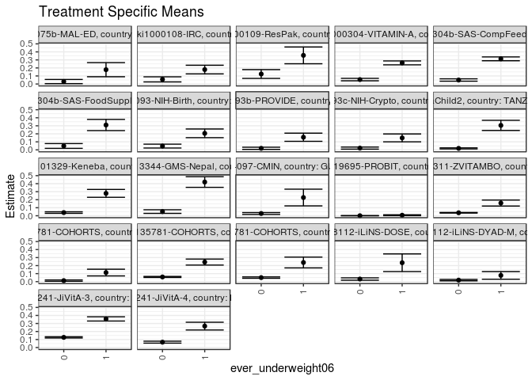

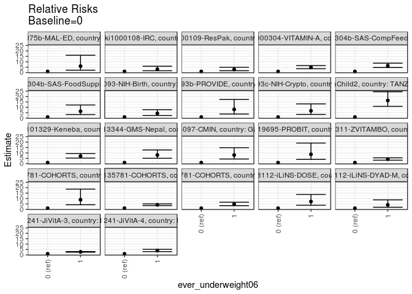

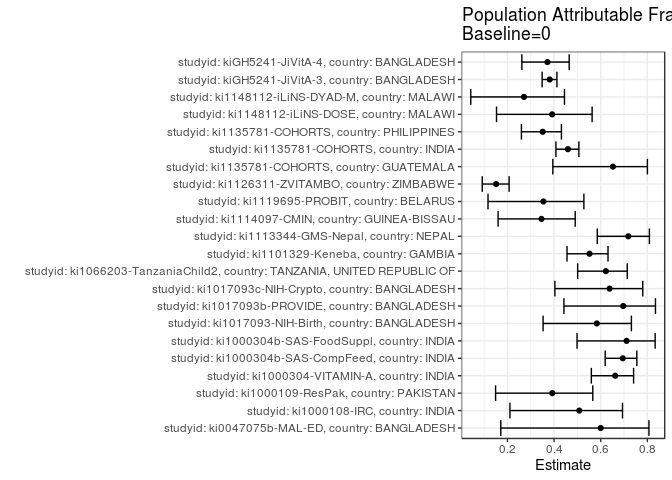

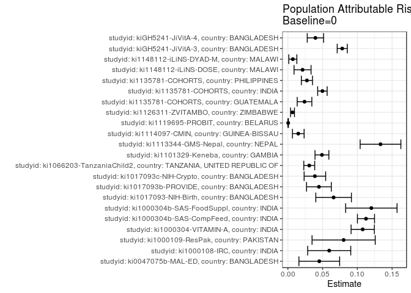

## Results Table

### Parameter: TSM

| studyid | country | intervention_level | baseline_level | estimate | ci_lower | ci_upper |
| --- | --- | --- | --- | --- | --- | --- |
| ki0047075b-MAL-ED | BANGLADESH | 0 | NA | 0.0301205 | 0.0040653 | 0.0561757 |
| ki0047075b-MAL-ED | BANGLADESH | 1 | NA | 0.1780822 | 0.0901351 | 0.2660293 |
| ki1000108-IRC | INDIA | 0 | NA | 0.0575813 | 0.0258645 | 0.0892981 |
| ki1000108-IRC | INDIA | 1 | NA | 0.1795636 | 0.1256077 | 0.2335196 |
| ki1000109-ResPak | PAKISTAN | 0 | NA | 0.1242824 | 0.0695576 | 0.1790072 |
| ki1000109-ResPak | PAKISTAN | 1 | NA | 0.3566064 | 0.2520812 | 0.4611316 |
| ki1000304-VITAMIN-A | INDIA | 0 | NA | 0.0548931 | 0.0395082 | 0.0702780 |
| ki1000304-VITAMIN-A | INDIA | 1 | NA | 0.2628363 | 0.2385377 | 0.2871349 |
| ki1000304b-SAS-CompFeed | INDIA | 0 | NA | 0.0494278 | 0.0346995 | 0.0641561 |
| ki1000304b-SAS-CompFeed | INDIA | 1 | NA | 0.3133709 | 0.2893911 | 0.3373507 |
| ki1000304b-SAS-FoodSuppl | INDIA | 0 | NA | 0.0487928 | 0.0191216 | 0.0784639 |
| ki1000304b-SAS-FoodSuppl | INDIA | 1 | NA | 0.3098614 | 0.2402376 | 0.3794851 |
| ki1017093-NIH-Birth | BANGLADESH | 0 | NA | 0.0470185 | 0.0229828 | 0.0710542 |
| ki1017093-NIH-Birth | BANGLADESH | 1 | NA | 0.2059817 | 0.1518394 | 0.2601240 |
| ki1017093b-PROVIDE | BANGLADESH | 0 | NA | 0.0194647 | 0.0060975 | 0.0328319 |
| ki1017093b-PROVIDE | BANGLADESH | 1 | NA | 0.1573604 | 0.1064694 | 0.2082514 |
| ki1017093c-NIH-Crypto | BANGLADESH | 0 | NA | 0.0220566 | 0.0092428 | 0.0348705 |
| ki1017093c-NIH-Crypto | BANGLADESH | 1 | NA | 0.1491383 | 0.0999735 | 0.1983031 |
| ki1066203-TanzaniaChild2 | TANZANIA, UNITED REPUBLIC OF | 0 | NA | 0.0186809 | 0.0122552 | 0.0251066 |
| ki1066203-TanzaniaChild2 | TANZANIA, UNITED REPUBLIC OF | 1 | NA | 0.3050541 | 0.2418722 | 0.3682360 |
| ki1101329-Keneba | GAMBIA | 0 | NA | 0.0397763 | 0.0301814 | 0.0493712 |
| ki1101329-Keneba | GAMBIA | 1 | NA | 0.2789409 | 0.2300920 | 0.3277899 |
| ki1113344-GMS-Nepal | NEPAL | 0 | NA | 0.0522446 | 0.0295664 | 0.0749229 |
| ki1113344-GMS-Nepal | NEPAL | 1 | NA | 0.4202872 | 0.3541049 | 0.4864694 |
| ki1114097-CMIN | GUINEA-BISSAU | 0 | NA | 0.0283115 | 0.0168988 | 0.0397243 |
| ki1114097-CMIN | GUINEA-BISSAU | 1 | NA | 0.2272580 | 0.1231031 | 0.3314129 |
| ki1119695-PROBIT | BELARUS | 0 | NA | 0.0007852 | 0.0000497 | 0.0015207 |
| ki1119695-PROBIT | BELARUS | 1 | NA | 0.0068552 | 0.0013591 | 0.0123513 |
| ki1126311-ZVITAMBO | ZIMBABWE | 0 | NA | 0.0372227 | 0.0335998 | 0.0408455 |
| ki1126311-ZVITAMBO | ZIMBABWE | 1 | NA | 0.1583704 | 0.1211299 | 0.1956109 |
| ki1135781-COHORTS | GUATEMALA | 0 | NA | 0.0127660 | 0.0044746 | 0.0210573 |
| ki1135781-COHORTS | GUATEMALA | 1 | NA | 0.1131222 | 0.0713399 | 0.1549045 |
| ki1135781-COHORTS | INDIA | 0 | NA | 0.0584903 | 0.0521749 | 0.0648056 |
| ki1135781-COHORTS | INDIA | 1 | NA | 0.2441493 | 0.2067560 | 0.2815425 |
| ki1135781-COHORTS | PHILIPPINES | 0 | NA | 0.0505820 | 0.0420799 | 0.0590842 |
| ki1135781-COHORTS | PHILIPPINES | 1 | NA | 0.2387120 | 0.1713398 | 0.3060842 |
| ki1148112-iLiNS-DOSE | MALAWI | 0 | NA | 0.0327964 | 0.0181472 | 0.0474456 |
| ki1148112-iLiNS-DOSE | MALAWI | 1 | NA | 0.2357503 | 0.1257918 | 0.3457089 |
| ki1148112-iLiNS-DYAD-M | MALAWI | 0 | NA | 0.0191531 | 0.0103810 | 0.0279251 |
| ki1148112-iLiNS-DYAD-M | MALAWI | 1 | NA | 0.0778058 | 0.0302826 | 0.1253290 |
| kiGH5241-JiVitA-3 | BANGLADESH | 0 | NA | 0.1269535 | 0.1191772 | 0.1347299 |
| kiGH5241-JiVitA-3 | BANGLADESH | 1 | NA | 0.3566545 | 0.3303425 | 0.3829664 |
| kiGH5241-JiVitA-4 | BANGLADESH | 0 | NA | 0.0670434 | 0.0548866 | 0.0792002 |
| kiGH5241-JiVitA-4 | BANGLADESH | 1 | NA | 0.2671177 | 0.2187247 | 0.3155107 |

### Parameter: E(Y)

| studyid | country | intervention_level | baseline_level | estimate | ci_lower | ci_upper |
| --- | --- | --- | --- | --- | --- | --- |
| ki0047075b-MAL-ED | BANGLADESH | NA | NA | 0.0753138 | 0.0417869 | 0.1088408 |
| ki1000108-IRC | INDIA | NA | NA | 0.1170732 | 0.0859146 | 0.1482317 |
| ki1000109-ResPak | PAKISTAN | NA | NA | 0.2045455 | 0.1511224 | 0.2579685 |
| ki1000304-VITAMIN-A | INDIA | NA | NA | 0.1626016 | 0.1492881 | 0.1759151 |
| ki1000304b-SAS-CompFeed | INDIA | NA | NA | 0.1618625 | 0.1426768 | 0.1810483 |
| ki1000304b-SAS-FoodSuppl | INDIA | NA | NA | 0.1689008 | 0.1308276 | 0.2069740 |
| ki1017093-NIH-Birth | BANGLADESH | NA | NA | 0.1128405 | 0.0854611 | 0.1402198 |
| ki1017093b-PROVIDE | BANGLADESH | NA | NA | 0.0641447 | 0.0446535 | 0.0836359 |
| ki1017093c-NIH-Crypto | BANGLADESH | NA | NA | 0.0609418 | 0.0434802 | 0.0784034 |
| ki1066203-TanzaniaChild2 | TANZANIA, UNITED REPUBLIC OF | NA | NA | 0.0494534 | 0.0397554 | 0.0591514 |
| ki1101329-Keneba | GAMBIA | NA | NA | 0.0887872 | 0.0768581 | 0.1007163 |
| ki1113344-GMS-Nepal | NEPAL | NA | NA | 0.1855670 | 0.1539560 | 0.2171780 |
| ki1114097-CMIN | GUINEA-BISSAU | NA | NA | 0.0432802 | 0.0298127 | 0.0567476 |
| ki1119695-PROBIT | BELARUS | NA | NA | 0.0012159 | 0.0002433 | 0.0021885 |
| ki1126311-ZVITAMBO | ZIMBABWE | NA | NA | 0.0438689 | 0.0395328 | 0.0482049 |
| ki1135781-COHORTS | GUATEMALA | NA | NA | 0.0367171 | 0.0245975 | 0.0488367 |
| ki1135781-COHORTS | INDIA | NA | NA | 0.1082022 | 0.1003643 | 0.1160400 |
| ki1135781-COHORTS | PHILIPPINES | NA | NA | 0.0779833 | 0.0679723 | 0.0879943 |
| ki1148112-iLiNS-DOSE | MALAWI | NA | NA | 0.0539216 | 0.0384151 | 0.0694281 |
| ki1148112-iLiNS-DYAD-M | MALAWI | NA | NA | 0.0262664 | 0.0166615 | 0.0358713 |
| kiGH5241-JiVitA-3 | BANGLADESH | NA | NA | 0.2052021 | 0.1976666 | 0.2127376 |
| kiGH5241-JiVitA-4 | BANGLADESH | NA | NA | 0.1066772 | 0.0962568 | 0.1170977 |

### Parameter: RR

| studyid | country | intervention_level | baseline_level | estimate | ci_lower | ci_upper |
| --- | --- | --- | --- | --- | --- | --- |
| ki0047075b-MAL-ED | BANGLADESH | 0 | 0 | 1.000000 | 1.000000 | 1.000000 |
| ki0047075b-MAL-ED | BANGLADESH | 1 | 0 | 5.912329 | 2.183566 | 16.008504 |
| ki1000108-IRC | INDIA | 0 | 0 | 1.000000 | 1.000000 | 1.000000 |
| ki1000108-IRC | INDIA | 1 | 0 | 3.118437 | 1.663980 | 5.844212 |
| ki1000109-ResPak | PAKISTAN | 0 | 0 | 1.000000 | 1.000000 | 1.000000 |
| ki1000109-ResPak | PAKISTAN | 1 | 0 | 2.869323 | 1.689112 | 4.874168 |
| ki1000304-VITAMIN-A | INDIA | 0 | 0 | 1.000000 | 1.000000 | 1.000000 |
| ki1000304-VITAMIN-A | INDIA | 1 | 0 | 4.788150 | 3.564942 | 6.431065 |
| ki1000304b-SAS-CompFeed | INDIA | 0 | 0 | 1.000000 | 1.000000 | 1.000000 |
| ki1000304b-SAS-CompFeed | INDIA | 1 | 0 | 6.339971 | 4.635727 | 8.670750 |
| ki1000304b-SAS-FoodSuppl | INDIA | 0 | 0 | 1.000000 | 1.000000 | 1.000000 |
| ki1000304b-SAS-FoodSuppl | INDIA | 1 | 0 | 6.350561 | 3.317664 | 12.156027 |
| ki1017093-NIH-Birth | BANGLADESH | 0 | 0 | 1.000000 | 1.000000 | 1.000000 |
| ki1017093-NIH-Birth | BANGLADESH | 1 | 0 | 4.380864 | 2.464825 | 7.786342 |
| ki1017093b-PROVIDE | BANGLADESH | 0 | 0 | 1.000000 | 1.000000 | 1.000000 |
| ki1017093b-PROVIDE | BANGLADESH | 1 | 0 | 8.084391 | 3.784280 | 17.270755 |
| ki1017093c-NIH-Crypto | BANGLADESH | 0 | 0 | 1.000000 | 1.000000 | 1.000000 |
| ki1017093c-NIH-Crypto | BANGLADESH | 1 | 0 | 6.761605 | 3.468110 | 13.182770 |
| ki1066203-TanzaniaChild2 | TANZANIA, UNITED REPUBLIC OF | 0 | 0 | 1.000000 | 1.000000 | 1.000000 |
| ki1066203-TanzaniaChild2 | TANZANIA, UNITED REPUBLIC OF | 1 | 0 | 16.329757 | 10.927689 | 24.402318 |
| ki1101329-Keneba | GAMBIA | 0 | 0 | 1.000000 | 1.000000 | 1.000000 |
| ki1101329-Keneba | GAMBIA | 1 | 0 | 7.012742 | 5.207725 | 9.443384 |
| ki1113344-GMS-Nepal | NEPAL | 0 | 0 | 1.000000 | 1.000000 | 1.000000 |
| ki1113344-GMS-Nepal | NEPAL | 1 | 0 | 8.044602 | 5.076027 | 12.749266 |
| ki1114097-CMIN | GUINEA-BISSAU | 0 | 0 | 1.000000 | 1.000000 | 1.000000 |
| ki1114097-CMIN | GUINEA-BISSAU | 1 | 0 | 8.027047 | 4.358862 | 14.782178 |
| ki1119695-PROBIT | BELARUS | 0 | 0 | 1.000000 | 1.000000 | 1.000000 |
| ki1119695-PROBIT | BELARUS | 1 | 0 | 8.730077 | 3.986648 | 19.117378 |
| ki1126311-ZVITAMBO | ZIMBABWE | 0 | 0 | 1.000000 | 1.000000 | 1.000000 |
| ki1126311-ZVITAMBO | ZIMBABWE | 1 | 0 | 4.254678 | 3.297847 | 5.489122 |
| ki1135781-COHORTS | GUATEMALA | 0 | 0 | 1.000000 | 1.000000 | 1.000000 |
| ki1135781-COHORTS | GUATEMALA | 1 | 0 | 8.861237 | 4.197626 | 18.706174 |
| ki1135781-COHORTS | INDIA | 0 | 0 | 1.000000 | 1.000000 | 1.000000 |
| ki1135781-COHORTS | INDIA | 1 | 0 | 4.174186 | 3.461956 | 5.032942 |
| ki1135781-COHORTS | PHILIPPINES | 0 | 0 | 1.000000 | 1.000000 | 1.000000 |
| ki1135781-COHORTS | PHILIPPINES | 1 | 0 | 4.719305 | 3.398090 | 6.554224 |
| ki1148112-iLiNS-DOSE | MALAWI | 0 | 0 | 1.000000 | 1.000000 | 1.000000 |
| ki1148112-iLiNS-DOSE | MALAWI | 1 | 0 | 7.188298 | 3.766309 | 13.719436 |
| ki1148112-iLiNS-DYAD-M | MALAWI | 0 | 0 | 1.000000 | 1.000000 | 1.000000 |
| ki1148112-iLiNS-DYAD-M | MALAWI | 1 | 0 | 4.062311 | 1.892472 | 8.720005 |
| kiGH5241-JiVitA-3 | BANGLADESH | 0 | 0 | 1.000000 | 1.000000 | 1.000000 |
| kiGH5241-JiVitA-3 | BANGLADESH | 1 | 0 | 2.809331 | 2.549854 | 3.095212 |
| kiGH5241-JiVitA-4 | BANGLADESH | 0 | 0 | 1.000000 | 1.000000 | 1.000000 |
| kiGH5241-JiVitA-4 | BANGLADESH | 1 | 0 | 3.984252 | 3.070580 | 5.169793 |

### Parameter: PAR

| studyid | country | intervention_level | baseline_level | estimate | ci_lower | ci_upper |
| --- | --- | --- | --- | --- | --- | --- |
| ki0047075b-MAL-ED | BANGLADESH | 0 | NA | 0.0451933 | 0.0158694 | 0.0745173 |
| ki1000108-IRC | INDIA | 0 | NA | 0.0594919 | 0.0284715 | 0.0905122 |
| ki1000109-ResPak | PAKISTAN | 0 | NA | 0.0802630 | 0.0347875 | 0.1257386 |
| ki1000304-VITAMIN-A | INDIA | 0 | NA | 0.1077085 | 0.0909554 | 0.1244617 |
| ki1000304b-SAS-CompFeed | INDIA | 0 | NA | 0.1124347 | 0.1001355 | 0.1247339 |
| ki1000304b-SAS-FoodSuppl | INDIA | 0 | NA | 0.1201080 | 0.0831039 | 0.1571122 |
| ki1017093-NIH-Birth | BANGLADESH | 0 | NA | 0.0658220 | 0.0401942 | 0.0914497 |
| ki1017093b-PROVIDE | BANGLADESH | 0 | NA | 0.0446800 | 0.0268751 | 0.0624849 |
| ki1017093c-NIH-Crypto | BANGLADESH | 0 | NA | 0.0388852 | 0.0233737 | 0.0543967 |
| ki1066203-TanzaniaChild2 | TANZANIA, UNITED REPUBLIC OF | 0 | NA | 0.0307725 | 0.0229039 | 0.0386412 |
| ki1101329-Keneba | GAMBIA | 0 | NA | 0.0490109 | 0.0390375 | 0.0589842 |
| ki1113344-GMS-Nepal | NEPAL | 0 | NA | 0.1333224 | 0.1040043 | 0.1626405 |
| ki1114097-CMIN | GUINEA-BISSAU | 0 | NA | 0.0149686 | 0.0065637 | 0.0233736 |
| ki1119695-PROBIT | BELARUS | 0 | NA | 0.0004306 | 0.0000672 | 0.0007940 |
| ki1126311-ZVITAMBO | ZIMBABWE | 0 | NA | 0.0066462 | 0.0038130 | 0.0094794 |
| ki1135781-COHORTS | GUATEMALA | 0 | NA | 0.0239511 | 0.0134177 | 0.0344845 |
| ki1135781-COHORTS | INDIA | 0 | NA | 0.0497119 | 0.0428833 | 0.0565404 |
| ki1135781-COHORTS | PHILIPPINES | 0 | NA | 0.0274013 | 0.0193604 | 0.0354422 |
| ki1148112-iLiNS-DOSE | MALAWI | 0 | NA | 0.0211252 | 0.0088871 | 0.0333632 |
| ki1148112-iLiNS-DYAD-M | MALAWI | 0 | NA | 0.0071133 | 0.0013092 | 0.0129175 |
| kiGH5241-JiVitA-3 | BANGLADESH | 0 | NA | 0.0782486 | 0.0709854 | 0.0855117 |
| kiGH5241-JiVitA-4 | BANGLADESH | 0 | NA | 0.0396338 | 0.0278820 | 0.0513856 |

### Parameter: PAF

| studyid | country | intervention_level | baseline_level | estimate | ci_lower | ci_upper |
| --- | --- | --- | --- | --- | --- | --- |
| ki0047075b-MAL-ED | BANGLADESH | 0 | NA | 0.6000669 | 0.1713348 | 0.8069830 |
| ki1000108-IRC | INDIA | 0 | NA | 0.5081599 | 0.2106897 | 0.6935214 |
| ki1000109-ResPak | PAKISTAN | 0 | NA | 0.3923971 | 0.1491497 | 0.5661032 |
| ki1000304-VITAMIN-A | INDIA | 0 | NA | 0.6624075 | 0.5598893 | 0.7410455 |
| ki1000304b-SAS-CompFeed | INDIA | 0 | NA | 0.6946309 | 0.6192926 | 0.7550605 |
| ki1000304b-SAS-FoodSuppl | INDIA | 0 | NA | 0.7111159 | 0.4985901 | 0.8335613 |
| ki1017093-NIH-Birth | BANGLADESH | 0 | NA | 0.5833188 | 0.3528635 | 0.7317054 |
| ki1017093b-PROVIDE | BANGLADESH | 0 | NA | 0.6965500 | 0.4422711 | 0.8348985 |
| ki1017093c-NIH-Crypto | BANGLADESH | 0 | NA | 0.6380705 | 0.4035098 | 0.7803938 |
| ki1066203-TanzaniaChild2 | TANZANIA, UNITED REPUBLIC OF | 0 | NA | 0.6222531 | 0.5011803 | 0.7139393 |
| ki1101329-Keneba | GAMBIA | 0 | NA | 0.5520040 | 0.4555216 | 0.6313896 |
| ki1113344-GMS-Nepal | NEPAL | 0 | NA | 0.7184595 | 0.5853009 | 0.8088613 |
| ki1114097-CMIN | GUINEA-BISSAU | 0 | NA | 0.3458545 | 0.1597910 | 0.4907144 |
| ki1119695-PROBIT | BELARUS | 0 | NA | 0.3541814 | 0.1165915 | 0.5278722 |
| ki1126311-ZVITAMBO | ZIMBABWE | 0 | NA | 0.1515014 | 0.0919129 | 0.2071798 |
| ki1135781-COHORTS | GUATEMALA | 0 | NA | 0.6523154 | 0.3946600 | 0.8003030 |
| ki1135781-COHORTS | INDIA | 0 | NA | 0.4594352 | 0.4079905 | 0.5064094 |
| ki1135781-COHORTS | PHILIPPINES | 0 | NA | 0.3513737 | 0.2599398 | 0.4315111 |
| ki1148112-iLiNS-DOSE | MALAWI | 0 | NA | 0.3917758 | 0.1531008 | 0.5631868 |
| ki1148112-iLiNS-DYAD-M | MALAWI | 0 | NA | 0.2708147 | 0.0426633 | 0.4445933 |
| kiGH5241-JiVitA-3 | BANGLADESH | 0 | NA | 0.3813244 | 0.3488035 | 0.4122212 |
| kiGH5241-JiVitA-4 | BANGLADESH | 0 | NA | 0.3715304 | 0.2618288 | 0.4649289 |